# Instacard Project: Modelling 1

Nima Ramezani

19/04/2021

In this module we build a general model which for each customer, can estimate the likelihood of all products that he/she has at least once purchased. Product id, here, becomes a categorical feature and there is only one target: probability of the product type in the feature being in the next customer order or not.

So we convert a multi-class classification model into a binary classification. In this modelling, each product for each customer is one training row in the dataset and for each customer. We only include products that the customer has at least ordered once. If we include all products for all customers both train and test sets will be huge and the target becomes extremely imbalanced.

- Disadvantages: You cannot include customer’s behaviour in regards to other products as features for predicting a particular product
- Advantages:
- One model for all products rather than multiple models for multile products
- Fewer features but long training dataset

# Customer Sampling:

Including all customers leads to a huge training dataset which takes longer to be built and may not fit in memory. So we first pick a sample of customers randomly, and do the modelling. We will check later to see if adding more customers can improve model performance or not.

```r
user_subset_train = orders$user_id %>% unique %>% sample(20000)
user_subset_test  = orders$user_id %>% unique %>% setdiff(user_subset_train) %>% sample(2000)
```

# Split for features and labels:

Since orders exact dates are not known, we need to pick an order number (usually last order number) for each customer as the last order number up to the cutpoint for labeling.

All events prior to the cutpoint order numbers are used for building features and events associated with cutpoint order numbers make labels for the training dataset.

For example for one customer, if we pick order number 6 as the cutpoint, then we use information in orders 1 to 5 to create features for that customer at that point in time and contents of order 6 is used to generate label for the training dataset for that customer.

If last order is picked as cutpoint (rather than random), we will have the maximum number of rows in the training data. However, we can pick multiple order numbers as labeling cut-point and generate training data based on those picked cutpoint order numbers. Then row bind the generated training datasets to make a bigger and richer training dataset. Here we only use the last orders as cutpoints and generate one trainig dataset from that.

Function `build_training_pack` splits order-product events into feature_set and label_set and returns them back in a list pack:

```r
build_training_pack = function(orders, products, order_products_prior, cutpoint_split = 'last_order', customer_subset = NULL){

  order_products = order_products_prior %>%
    left_join(products, by = 'product_id') %>%
    left_join(orders %>%
                # filter(eval_set == 'prior') %>%
                select(-eval_set) %>%
                arrange(user_id, order_number) %>%
                mutate(day_number = days_since_prior_order %>% na2zero) %>%
                rutils::column.cumulative.forward(col = 'day_number', id_col = 'user_id')
              , by = 'order_id')
  if(!is.null(customer_subset)){
    order_products %<>% filter(user_id %in% customer_subset)
  }

  ### Pick cutpoint order numbers:
  order_products %>%
    arrange(user_id, order_number) %>%
    group_by(user_id) %>%
    summarise(cutpoint_order_number = max(order_number),
              cutpoint_order_id = last(order_id)) %>%
    ungroup -> cutpoint_orders

  order_products %<>%
    left_join(cutpoint_orders, by = 'user_id') %>%
    mutate(flag_label = order_number == cutpoint_order_number,
           flag_feature = order_number < cutpoint_order_number)

  ind_features = which(order_products$flag_feature)
  ind_labels   = which(order_products$flag_label)

  cat('\n', '%s rows total, %s rows for feature aggregation, %s rows for labeling, %s rows removed!' %>%
        sprintf(nrow(order_products),
                length(ind_features),
                length(ind_labels),
                nrow(order_products) - length(ind_features) - length(ind_labels)))

  return(list(feature_dataset = order_products[ind_features,], label_dataset = order_products[ind_labels,], cutpoint_orders = cutpoint_orders))
}
```

Now we use this function to make two separate dataset packs for train and test:

```r
train_pack = build_training_pack(orders, products, order_products_prior, customer_subset = user_subset_train)
```

```
##
##  3102873 rows total, 2894797 rows for feature aggregation, 208076 rows for labeling, 0 rows removed!
```

```r
test_pack  = build_training_pack(orders, products, order_products_prior, customer_subset = user_subset_test)
```

```
##
##  304454 rows total, 283809 rows for feature aggregation, 20645 rows for labeling, 0 rows removed!
```

```r
head(train_pack$feature_dataset, n = 100) %>% DT::datatable()
```

|  | order_id | product_id | add_to_cart_order | reordered | product_name | aisle_id | department_id | user_id | order_number | order_dow | order_hour_of_day | days_since_prior_order | day_number | cutpoint_order_number | cutpoint_order_id | flag_label | flag_feature |
| --- | --- | --- | --- | --- | --- | --- | --- | --- | --- | --- | --- | --- | --- | --- | --- | --- | --- |
| 1 | 7 | 34050 | 1 | 0 | Orange Juice | 31 | 7 | 142903 | 11 | 2 | 14 | 30 | 150 | 12 | 3112428 | False | True |
| 2 | 7 | 46802 | 2 | 0 | Pineapple Chunks | 116 | 1 | 142903 | 11 | 2 | 14 | 30 | 150 | 12 | 3112428 | False | True |
| 3 | 11 | 30162 | 1 | 1 | Teriyaki &amp; Pineapple Chicken Meatballs | 38 | 1 | 143742 | 4 | 1 | 19 | 23 | 60 | 15 | 3098971 | False | True |
| 4 | 11 | 27085 | 2 | 1 | Mango Pineapple Salsa | 67 | 20 | 143742 | 4 | 1 | 19 | 23 | 60 | 15 | 3098971 | False | True |
| 5 | 11 | 5994 | 3 | 1 | Traditional Refried Beans | 59 | 15 | 143742 | 4 | 1 | 19 | 23 | 60 | 15 | 3098971 | False | True |
| 6 | 11 | 1313 | 4 | 1 | Tortilla Strips Restaurant Style | 107 | 19 | 143742 | 4 | 1 | 19 | 23 | 60 | 15 | 3098971 | False | True |
| 7 | 11 | 31506 | 5 | 1 | Extra Virgin Olive Oil | 19 | 13 | 143742 | 4 | 1 | 19 | 23 | 60 | 15 | 3098971 | False | True |
| 8 | 15 | 19660 | 1 | 1 | Spring Water | 115 | 7 | 54901 | 51 | 3 | 11 | 2 | 152 | 99 | 1078113 | False | True |
| 9 | 15 | 21195 | 2 | 1 | Organic Extra Virgin Olive Oil | 19 | 13 | 54901 | 51 | 3 | 11 | 2 | 152 | 99 | 1078113 | False | True |
| 10 | 15 | 7461 | 3 | 1 | Pinto Beans No Salt Added | 59 | 15 | 54901 | 51 | 3 | 11 | 2 | 152 | 99 | 1078113 | False | True |

[output cut: 90 more lines]

```r
# saveRDS(train_pack, 'data/train_pack.rds')
# saveRDS(test_pack, 'data/test_pack.rds')
# train_pack =  readRDS('data/train_pack.rds')
# test_pack  =  readRDS('data/test_pack.rds')
```

# Building Features from datasets

Function `build_features` extracts features from the pack returned by function `build_training_pack`. This function is fully explained in the feature engineering report.

```r
train = build_features(train_pack$feature_dataset)
test  = build_features(test_pack$feature_dataset)
exclude_columns = colnames(train) %>% charFilter('_')
X_train = train[colnames(train) %-% exclude_columns]
X_test  = test[colnames(test) %-% exclude_columns]

train %>% head(100) %>%
  DT::datatable()
```

|  | user_id | product_id | CustomerProductOrderFrequency | CustomerProductReorderFrequency | CustomerProductFirstSelectionFrequency | CustomerProductFirstTwoSelectionsFrequency | CustomerProductFirstThreeSelections | CustomerProductAverageOrderGap | CustomerProductVarianceOrderGap | CustomerProductIsInCurrentOrder | day_number_last_product_ordered | day_number_nextlast_product_ordered | order_number_last_product_ordered | order_number_nextlast_product_ordered | ProductPopularity | ProductReorderFrequency | ProductPreferredOrderHour | ProductLatestOrderHour | ProductEarliestOrderHour | ProductPreferredDOW | ProductReorderRate | product_name | aisle_id | department_id | ProductAverageOrderGap | ProductFirstSelectionFrequency | ProductOrderPace | current_order_id | current_order_number | … |
| --- | --- | --- | --- | --- | --- | --- | --- | --- | --- | --- | --- | --- | --- | --- | --- | --- | --- | --- | --- | --- | --- | --- | --- | --- | --- | --- | --- | --- | --- | --- |
| 1 | 8 | 651 | 1 | 0 | 0 | 0 | 0 | -1 |  | 0 | 0 | -1 | 1 | -1 | 1310 | 720 | 13 | 23 | 0 | 0 | 0.549618320610687 | Organic Salted Butter | 36 | 16 | 25.8174887118531 | 126 | 0.0387334341910988 | 2979257 | 2 | … |
| 2 | 8 | 1529 | 1 | 0 | 0 | 0 | 0 | -1 |  | 0 | 0 | -1 | 1 | -1 | 768 | 332 | 11 | 23 | 0 | 0 | 0.432291666666667 | Parsley, Italian (Flat), New England Grown | 16 | 4 | 16.4892242247264 | 64 | 0.060645666913817 | 2979257 | 2 | … |
| 3 | 8 | 2078 | 2 | 1 | 0 | 0 | 0 | 15 | 450 | 1 | 30 | 0 | 2 | 1 | 1771 | 1159 | 13 | 23 | 0 | 0 | 0.654432523997741 | Unsalted Pure Irish Butter | 36 | 16 | 26.0121727642969 | 216 | 0.0384435398404147 | 2979257 | 2 | … |
| 4 | 8 | 6141 | 1 | 0 | 0 | 0 | 0 | -1 |  | 0 | 0 | -1 | 1 | -1 | 284 | 74 | 14 | 23 | 0 | 0 | 0.26056338028169 | Low Sodium Beef Broth | 69 | 15 | 15.002619047619 | 21 | 0.0666550284870896 | 2979257 | 2 | … |
| 5 | 8 | 6473 | 1 | 0 | 0 | 0 | 1 | -1 |  | 0 | 0 | -1 | 1 | -1 | 409 | 198 | 11 | 23 | 0 | 5 | 0.484107579462103 | Bag of Lemons | 24 | 4 | 14.6152387107363 | 47 | 0.0684217356823191 | 2979257 | 2 | … |
| 6 | 8 | 9839 | 2 | 1 | 1 | 1 | 1 | 15 | 450 | 1 | 30 | 0 | 2 | 1 | 3312 | 2307 | 14 | 23 | 0 | 0 | 0.696557971014493 | Organic Broccoli | 83 | 4 | 21.7697313471739 | 296 | 0.0459353394882301 | 2979257 | 2 | … |
| 7 | 8 | 11136 | 1 | 0 | 0 | 0 | 0 | -1 |  | 1 | 30 | -1 | 2 | -1 | 528 | 214 | 11 | 23 | 0 | 0 | 0.40530303030303 | Organic Low Sodium Chicken Cooking Stock | 69 | 15 | 18.8130800727934 | 32 | 0.0531545071902474 | 2979257 | 2 | … |
| 8 | 8 | 14992 | 2 | 1 | 0 | 1 | 1 | 15 | 450 | 1 | 30 | 0 | 2 | 1 | 2746 | 1637 | 12 | 23 | 0 | 0 | 0.596139839766934 | Green Beans | 83 | 4 | 20.7620786395409 | 184 | 0.0481647342427229 | 2979257 | 2 | … |
| 9 | 8 | 16349 | 1 | 0 | 0 | 0 | 0 | -1 |  | 0 | 0 | -1 | 1 | -1 | 1907 | 1098 | 10 | 23 | 0 | 0 | 0.575773466177242 | Organic Yams | 83 | 4 | 18.6098572553746 | 118 | 0.0537349634807756 | 2979257 | 2 | … |
| 10 | 8 | 17794 | 2 | 1 | 0 | 0 | 0 | 15 | 450 | 1 | 30 | 0 | 2 | 1 | 6952 | 4504 | 15 | 23 | 0 | 0 | 0.647871116225547 | Carrots | 83 | 4 | 24.0197328205202 | 497 | 0.0416324364418282 | 2979257 | 2 | … |

[output cut: 90 more lines]

Function `build_labels` extracts labels from the pack returned by function `build_training_pack` by joining the labeling dataset of to a given list of `user_id`s and `product_id`s. If there is no event in the `labeling_dataset` for a user and profile, the value of any column joined will be missing and we use this flag to build a binary label for each customer and profile:

```r
build_labels = function(id_set, label_dataset){
  id_set %>%
    left_join(label_dataset[, c('user_id', 'product_id', 'reordered')], by = c('user_id', 'product_id')) %>%
    mutate(label = as.numeric(!is.na(reordered))) %>%
    pull(label)
}
```

We build labels for both train and test datasets:

```r
y_train = train %>% select(user_id, product_id) %>% build_labels(train_pack$label_dataset)
y_test  = test %>% select(user_id, product_id) %>% build_labels(test_pack$label_dataset)
```

## XGBoost model

We have now what we need to build a classifier model. We use the R package **RML** to train a XGBoost model with default hyper-parameters and evaluate model performance with test data:

```r
xgb = rml::CLS.SKLEARN.XGB(name = 'xgb_v1', n_jobs = 8, fe.enabled = T)

xgb$fit(X_train, y_train)

xgb$performance(X_test, y_test,
                metrics = c('gini', 'precision', 'recall', 'lift', 'accuracy', 'f1'),
                quantiles = c(0.02, 0.05, 0.1, 0.2, 0.5)) %>%
as.data.frame %>% t %>% {colnames(.) <- 'Value';.} %>% knitr::kable()
```

|  | Value |
| --- | --- |
| gini | 0.6265597 |
| precision_2pc | 0.6201717 |
| recall_2pc | 0.1188616 |
| lift_2pc | 5.9426189 |
| accuracy_2pc | 0.9004472 |
| f1_2pc | 0.1994892 |
| precision_5pc | 0.5217167 |
| recall_5pc | 0.2499794 |
| lift_5pc | 4.9992025 |
| accuracy_5pc | 0.8978118 |
| f1_5pc | 0.3380047 |
| precision_10pc | 0.4234203 |
| recall_10pc | 0.4056922 |
| lift_10pc | 4.0573051 |
| accuracy_10pc | 0.8803255 |
| f1_10pc | 0.4143667 |
| precision_20pc | 0.3126449 |
| recall_20pc | 0.5991610 |
| lift_20pc | 2.9958306 |
| accuracy_20pc | 0.8206986 |
| f1_20pc | 0.4108870 |
| precision_50pc | 0.1824878 |
| recall_50pc | 0.8743111 |
| lift_50pc | 1.7486372 |
| accuracy_50pc | 0.5781305 |
| f1_50pc | 0.3019516 |
| precision | 0.4155631 |
| recall | 0.4155631 |
| lift | 3.9820149 |
| accuracy | 0.8780163 |
| f1 | 0.4155631 |

Here is the ROC-curve for the prediction:

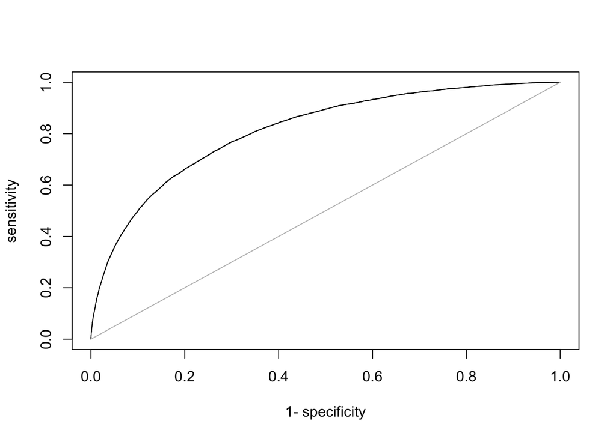

```r
plot(AUC::roc(predictions = xgb$predict(X_test)[,1], labels = y_test %>% as.factor))
```

Let’s have a look at the most 20 Important Features:

```r
xgb$objects$features %>% arrange(desc(importance)) %>% head(20) %>%
  rename(Feature = fname, Importance = importance) %>%
  plotly::plot_ly(y = ~Feature, x = ~Importance, type = 'bar')
```

[interactive chart not shown]

```r
test_pack$cutpoint_orders %>%
  rename(order_id = cutpoint_order_id) %>%
  left_join(order_products_prior, by = 'order_id') -> actual_orders

actual_orders %>%
  group_by(user_id) %>%
  summarise(order_size = length(unique(product_id))) %>%
  ungroup -> actual_order_sizes

threshold = 0.5

test %>%
  as.data.frame %>%
  cbind(xgb$predict(X_test), label = y_test) %>%
  group_by(user_id) %>%
  summarise(order_size_expected = sum(label, na.rm = T),
            tp = sum((xgb_v1_probs > threshold) & (label == 1)),
            fp = sum((xgb_v1_probs > threshold) & (label == 0)),
            tn = sum((xgb_v1_probs < threshold) & (label == 0)),
            fn = sum((xgb_v1_probs < threshold) & (label == 1))) %>%
  ungroup %>%
  mutate(precision = tp/(tp + fp), recall = tp/(tp + fn)) %>%
  left_join(actual_order_sizes, by = 'user_id') %>%
  mutate(f1 = 2*precision*recall/(precision + recall)) %>%
  arrange(desc(f1), desc(order_size)) %>%
  {rownames(.) <- NULL;.} -> res

res %>% DT::datatable()
```

|  | user_id | order_size_expected | tp | fp | tn | fn | precision | recall | order_size | f1 |
| --- | --- | --- | --- | --- | --- | --- | --- | --- | --- | --- |
| 1 | 142953 | 1 | 1 | 0 | 12 | 0 | 1 | 1 | 11 | 1 |
| 2 | 193998 | 1 | 1 | 0 | 1 | 0 | 1 | 1 | 9 | 1 |
| 3 | 74265 | 1 | 1 | 0 | 4 | 0 | 1 | 1 | 7 | 1 |
| 4 | 200534 | 1 | 1 | 0 | 2 | 0 | 1 | 1 | 7 | 1 |
| 5 | 22572 | 3 | 3 | 0 | 8 | 0 | 1 | 1 | 5 | 1 |
| 6 | 171213 | 1 | 1 | 0 | 1 | 0 | 1 | 1 | 5 | 1 |
| 7 | 200519 | 1 | 1 | 0 | 24 | 0 | 1 | 1 | 5 | 1 |
| 8 | 69312 | 2 | 2 | 0 | 107 | 0 | 1 | 1 | 4 | 1 |
| 9 | 52947 | 1 | 1 | 0 | 12 | 0 | 1 | 1 | 3 | 1 |
| 10 | 74559 | 2 | 2 | 0 | 1 | 0 | 1 | 1 | 3 | 1 |

[output cut: 1990 more lines]

Histogram of f1 scores based on 50% probability boundary cut:

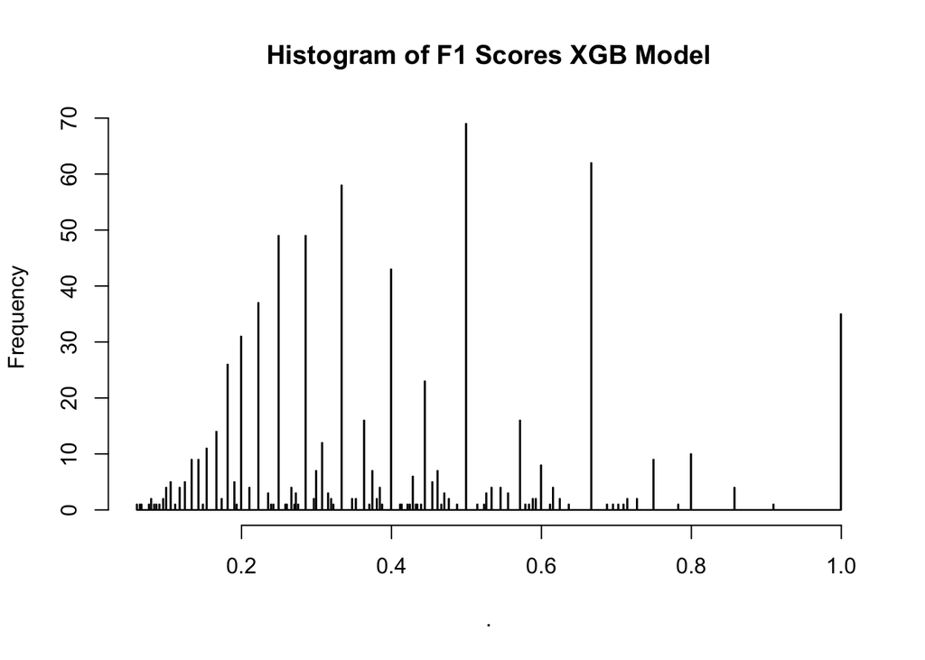

```r
res %>% filter(order_size_expected > 0) %>% pull(f1) %>% hist(breaks = 1000, main = 'Histogram of F1 Scores XGB Model')
```